# DATA 624 Homework 6 Chapter 8

## Question 8.6

**Use R to simulate and plot some data from simple ARIMA models.** Use the following R code to generate data from an AR(1) model (Take parameters given in text)

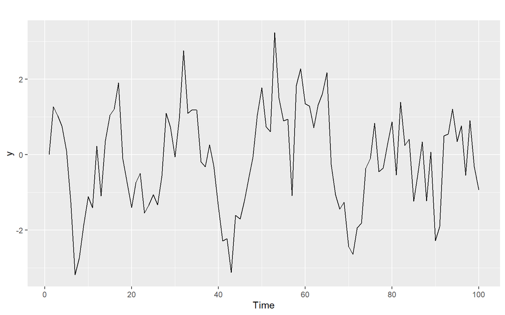

```r
y <- ts(numeric(100))
e <- rnorm(100)
for(i in 2:100)
  y[i] <- 0.6*y[i-1] + e[i]

autoplot(y)
```

**Produce a time-series plot for the series. How does the plot change as you change phi?**

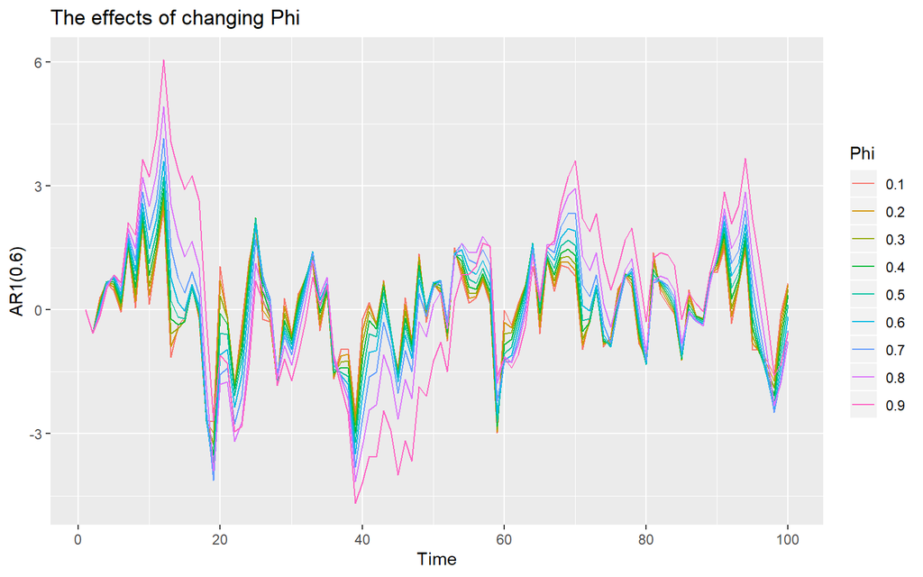

```r
AR1 <- function(phi){
  set.seed(42)
  y <- ts(numeric(100))
  e <- rnorm(100)
  for(i in 2:100){
    y[i] <- phi*y[i-1] + e[i]
  }
  return(y)
}

p <- autoplot(AR1(0.6))
for(phi in seq(0.1, 0.9, 0.1)){
  p <- p + autolayer(AR1(phi), series = paste(phi))
}
p +
  labs(title="The effects of changing Phi", color = "Phi")
```

Now with a fixed random number seed we can see the effect. As ϕ1 increases, the distance from zero increases. It increases the autocorrelation with the preceeding value.

**Write your own code to generate data from an MA(1) model with θ1=0.6 and σ2=1.**

```r
MA1 <- function(theta){
  set.seed(42)
  y <- ts(numeric(100))
  e <- rnorm(100)
  e[1] <- 0
  for(i in 2:100){
    y[i] <- theta*e[i-1] + e[i]
  }
  return(y)
}
```

**Produce a time plot for the series. How does the plot change as you change θ1?**

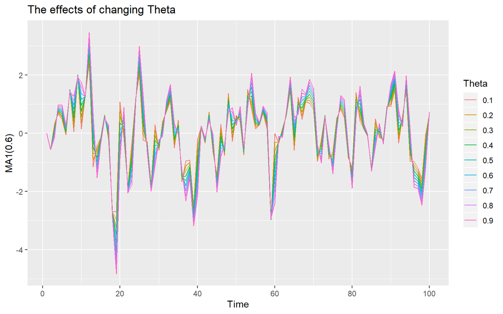

```r
p <- autoplot(MA1(0.6))
for(theta in seq(0.1, 0.9, 0.1)){
  p <- p + autolayer(MA1(theta), series = paste(theta))
}

p +
  labs(title="The effects of changing Theta", color = "Theta")
```

As theta increases the distance from zero increases

**Generate data from an ARMA(1,1) model with ϕ1=0.6, θ1=0.6 and σ2=1.**

```r
ARMA <- function(phi, theta){
  set.seed(42)
  y <- ts(numeric(100))
  e <- rnorm(100)
  e[1] <- 0
  for(i in 2:100)
    y[i] <- phi*y[i-1] + theta*e[i-1] + e[i]
  return(y)
}
```

**Generate data from an AR(2) model with ϕ1=−0.8, ϕ2=0.3 and σ2=1. (Note that these parameters will give a non-stationary series.)**

```r
AR2 <- function(phi_1, phi_2){
  set.seed(42)
  y <- ts(numeric(100))
  e <- rnorm(100)
  for(i in 3:100)
    y[i] <- phi_1*y[i-1] + phi_2*y[i-2] + e[i]
  return(y)
}
```

**Graph the latter two series and compare them.**

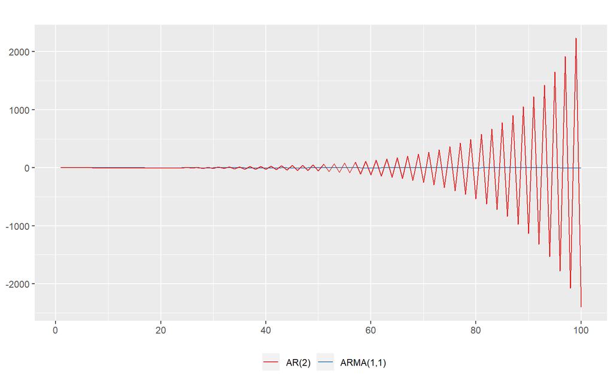

```r
autoplot(ARMA(0.6, 0.6), series = "ARMA(1,1)") +
  autolayer(AR2(-0.8, 0.3), series = "AR(2)") +
  theme(axis.title = element_blank(), legend.position = "bottom", legend.title = element_blank()) +
  scale_color_brewer(palette = "Set1")
```

## Question 8.7

Consider wmurders, the number of women murdered each year (per 100,000 standard population) in the United States.

**By studying appropriate graphs of the series in R, find an appropriate ARIMA(p,d,q) model for these data.**

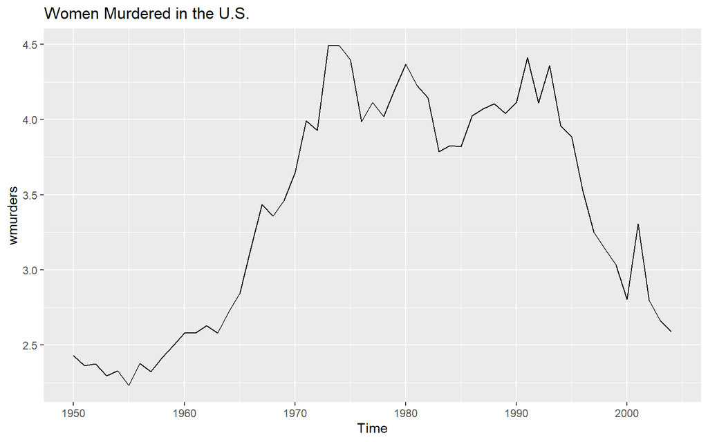

```r
autoplot(wmurders) +
  ggtitle("Women Murdered in the U.S.")
```

take a look at what the ndiffs function says about this time series, it says the series should be differenced twice

```r
ndiffs(wmurders)
```

```
## [1] 2
```

Plot the differenced function

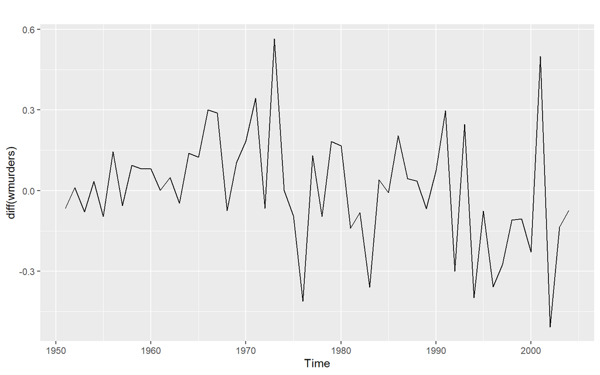

```r
autoplot(diff(wmurders))
```

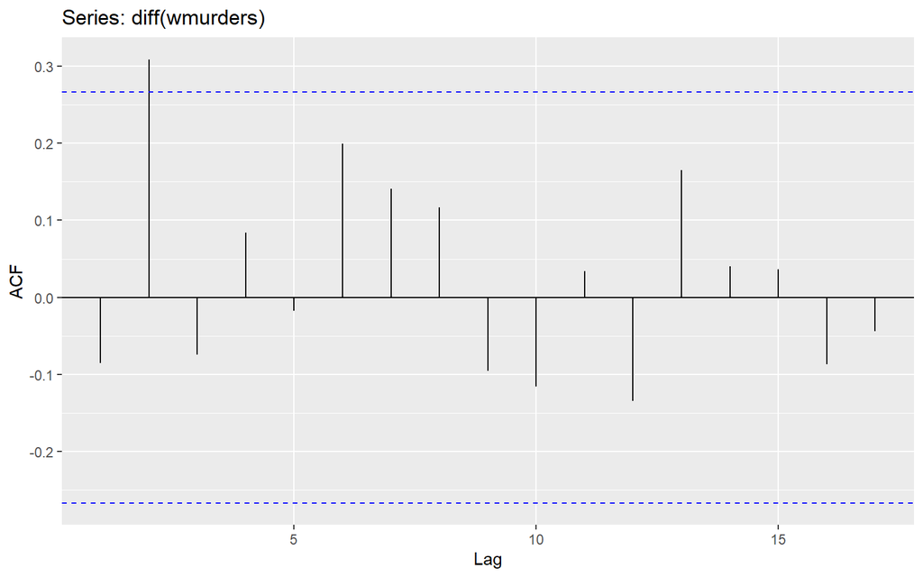

```r
ggAcf(diff(wmurders))
```

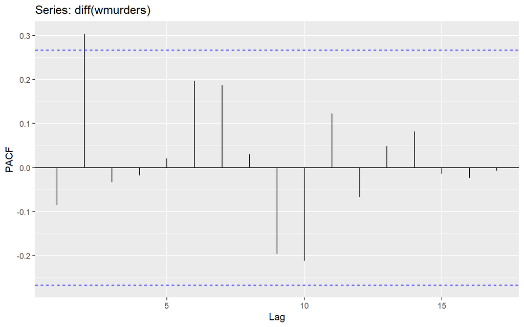

```r
ggPacf(diff(wmurders))
```

Plot the twice differenced function

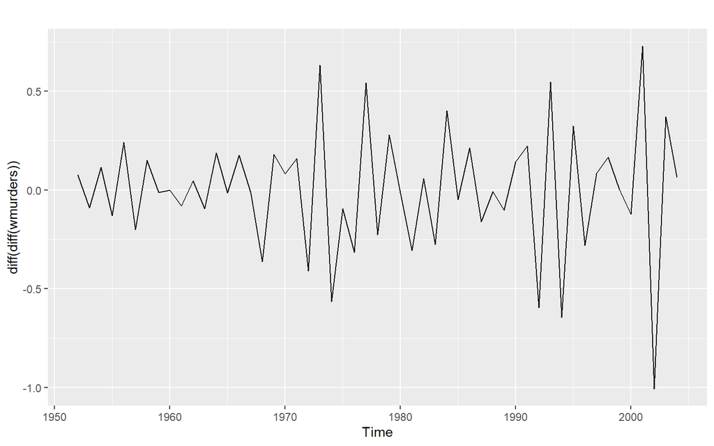

```r
autoplot(diff(diff(wmurders)))
```

**Should you include a constant in the model? Explain.** In an ideal world, we’d like the long-term forecasts to tend towards zero, however realistically this won’t be the case. Instead, we’d like it to go towards some non-zero constant, preferably low. According to Hyndman, that would happen if c = 0 and d = 1, so we won’t be adding a constant.

As of now, the model looks like it should be ARIMA(0,1,2)

**Fit the model using R and examine the residuals. Is the model satisfactory?**

```r
fit <- Arima(wmurders, order = c(0,1,2))
fit
```

```
## Series: wmurders
## ARIMA(0,1,2)
##
## Coefficients:
##           ma1     ma2
##       -0.0660  0.3712
## s.e.   0.1263  0.1640
##
## sigma^2 estimated as 0.0422:  log likelihood=9.71
## AIC=-13.43   AICc=-12.95   BIC=-7.46
```

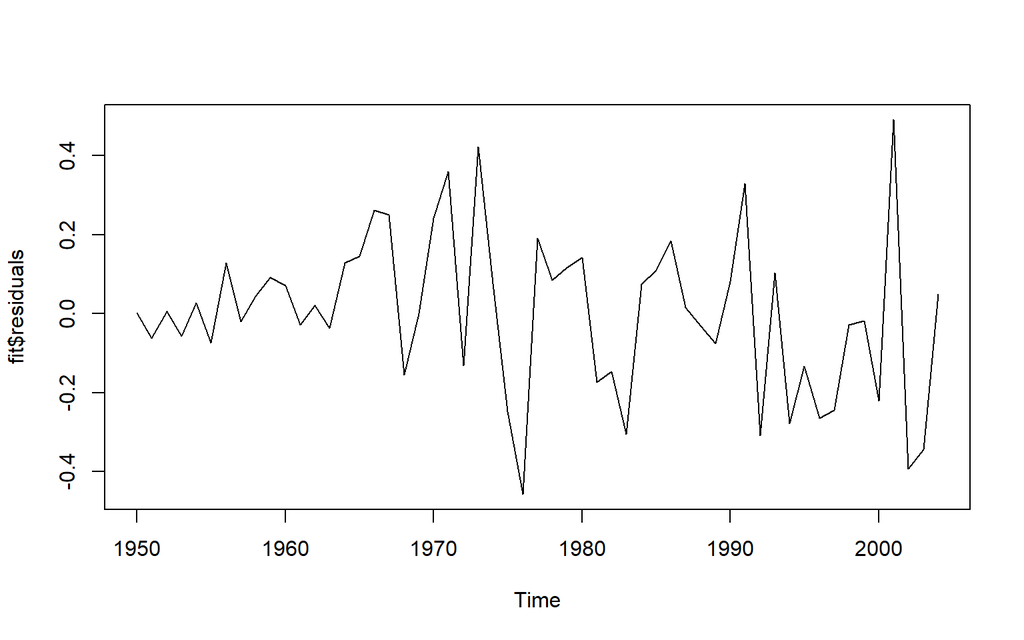

```r
plot(fit$residuals)
```

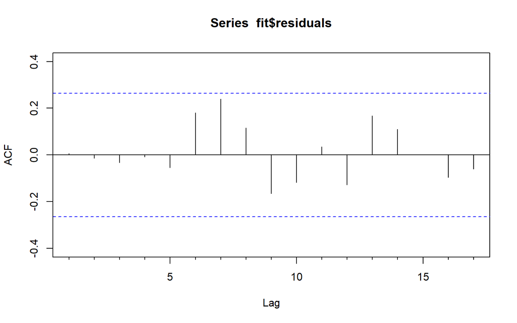

```r
Acf(fit$residuals)
```

Our model appears satisfactory. The residuals are all within the bounds. The plot vaguely resembles white noise.

**Forecast three times ahead. Check your forecasts by hand to make sure that you know periods shown.**

```r
fcast <- forecast(fit, h=3)
fcast
```

```
##      Point Forecast    Lo 80    Hi 80    Lo 95    Hi 95
## 2005       2.458450 2.195194 2.721707 2.055834 2.861066
## 2006       2.477101 2.116875 2.837327 1.926183 3.028018
## 2007       2.477101 1.979272 2.974929 1.715738 3.238464
```

To calculate this by hand, we’ll be utilizing the equations from above for AR and MA, where yt=c+yt−1+et. Although for the prediction, we set ϵT+1=0.

```r
c <- fit$coef[1]
yt <- wmurders[55]
et <- 0
f2005 <- c + yt + et
f2006 <- c + f2005
f2007 <- c + f2006

c(f2005, f2006, f2007)
```

```
##      ma1      ma1      ma1
## 2.523390 2.457397 2.391403
```

Except the calculations don’t line up with the model. Presumably, while we know yt, as it is the last known value from wmurders, we are missing the last, corresponding ϵT value.

**Create a plot of the series with forecasts and prediction intervals for the next three periods shown.**

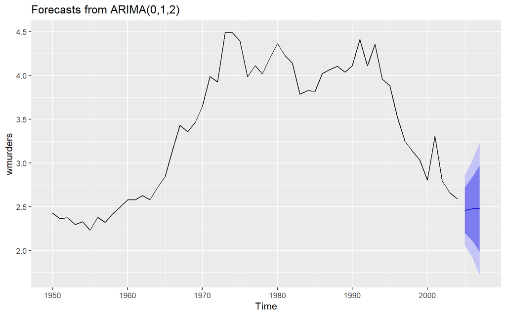

```r
autoplot(fcast)
```

**Does auto.arima() give the same model you have chosen? If not, which model do you think is better?**

```r
autofit <- auto.arima(wmurders, seasonal = FALSE,
                      stepwise = FALSE, approximation = FALSE)
autofit
```

```
## Series: wmurders
## ARIMA(0,2,3)
##
## Coefficients:
##           ma1     ma2      ma3
##       -1.0154  0.4324  -0.3217
## s.e.   0.1282  0.2278   0.1737
##
## sigma^2 estimated as 0.04475:  log likelihood=7.77
## AIC=-7.54   AICc=-6.7   BIC=0.35
```

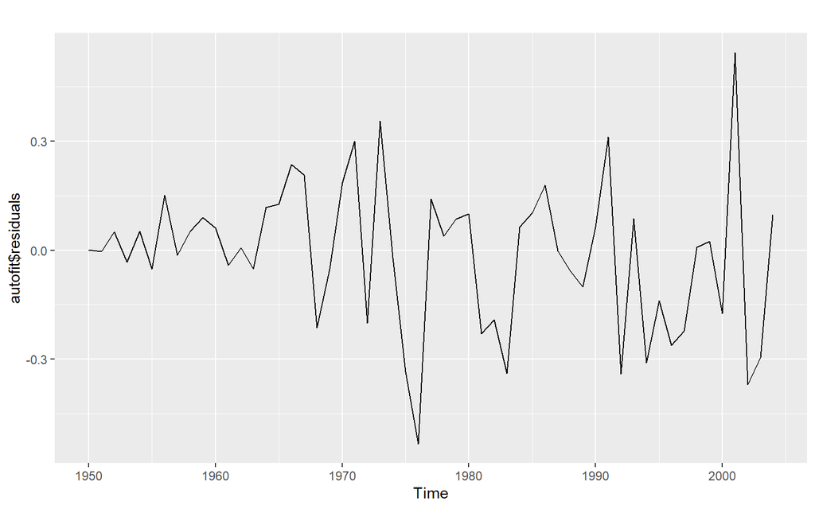

```r
autoplot(autofit$residuals)
```

2020-03-22